# Интернет-магазин "Продукты питания": воронка событий.

# Table of Contents

## Общее описание проекта и исходные данные

Стартап "Продукты питания" продаёт продукты питания.

Дизайнеры предложили поменять шрифты во всём приложении. Решение об изменении шрифтов будет принято по результатам A/A/B-теста.

Пользователей разбили на 3 группы: 2 контрольные со старыми шрифтами и одну экспериментальную — с новыми.

**Задача исследования:**

изучить воронку событий и проверить гипотезу об изменении в воронке после внедрения новых шрифтов.

```python
import pandas as pd
from scipy import stats as st
import datetime as dt
import numpy as np
import matplotlib.pyplot as plt
from matplotlib.ticker import MultipleLocator
import math as mth
```

```python
import warnings
warnings.filterwarnings(action='ignore')
```

## Часть 1. Проверка данных.

```python
logs.head()
```

|  | EventName | DeviceIDHash | EventTimestamp | ExpId |
| --- | --- | --- | --- | --- |
| 0 | MainScreenAppear | 4575588528974610257 | 1564029816 | 246 |
| 1 | MainScreenAppear | 7416695313311560658 | 1564053102 | 246 |
| 2 | PaymentScreenSuccessful | 3518123091307005509 | 1564054127 | 248 |
| 3 | CartScreenAppear | 3518123091307005509 | 1564054127 | 248 |
| 4 | PaymentScreenSuccessful | 6217807653094995999 | 1564055322 | 248 |

```python
logs.info()
```

```
<class 'pandas.core.frame.DataFrame'>
RangeIndex: 244126 entries, 0 to 244125
Data columns (total 4 columns):
 #   Column          Non-Null Count   Dtype
---  ------          --------------   -----
 0   EventName       244126 non-null  object
 1   DeviceIDHash    244126 non-null  int64
 2   EventTimestamp  244126 non-null  int64
 3   ExpId           244126 non-null  int64
dtypes: int64(3), object(1)
memory usage: 7.5+ MB
```

```python
logs.columns=['event', 'user_id', 'time_stamp', 'exp_id']
```

Обработали даты, time_stamp сохранили для дальнейшего применения.

```python
logs['date_time'] = pd.to_datetime(logs['time_stamp'], unit='s')
```

```python
logs['date'] = logs['date_time'].dt.to_period('d')
```

```python
logs.isna().sum()
```

```
event         0
user_id       0
time_stamp    0
exp_id        0
date_time     0
date          0
dtype: int64
```

```python
logs.duplicated().sum()
```

```
413
```

```python
print('Доля дубликатов: {:.2%}.'.format(logs.duplicated().sum() / logs.shape[0]))
```

```
Доля дубликатов: 0.17%.
```

По смыслу исходных данных дубликатов быть не должно, их доля незначительна ==> удалили дубликаты.

```python
logs.drop_duplicates(inplace=True)
logs.duplicated().sum()
```

```
0
```

```python
logs.head()
```

|  | event | user_id | time_stamp | exp_id | date_time | date |
| --- | --- | --- | --- | --- | --- | --- |
| 0 | MainScreenAppear | 4575588528974610257 | 1564029816 | 246 | 2019-07-25 04:43:36 | 2019-07-25 |
| 1 | MainScreenAppear | 7416695313311560658 | 1564053102 | 246 | 2019-07-25 11:11:42 | 2019-07-25 |
| 2 | PaymentScreenSuccessful | 3518123091307005509 | 1564054127 | 248 | 2019-07-25 11:28:47 | 2019-07-25 |
| 3 | CartScreenAppear | 3518123091307005509 | 1564054127 | 248 | 2019-07-25 11:28:47 | 2019-07-25 |
| 4 | PaymentScreenSuccessful | 6217807653094995999 | 1564055322 | 248 | 2019-07-25 11:48:42 | 2019-07-25 |

**Промежуточные выводы:**

- данные соответствуют описанию;
- в данные внесены минимальные коррективы: удалено незначительное число дубликатов, преобразованы данные о датах;
- данные готовы для исследования.

## Часть 2. Изучение данных.

**Сколько всего событий в логе?**

```python
print('Всего в логе {} событий.'.format(logs.shape[0]))
```

```
Всего в логе 243713 событий.
```

**Сколько всего пользователей в логе?**

```python
print('Всего в логе {} уникальных пользователей.'.format(logs['user_id'].nunique()))
```

```
Всего в логе 7551 уникальных пользователей.
```

**Сколько в среднем событий приходится на пользователя?**

```python
print('В среднем на одного уникального пользователя приходится {:.2f} событий.'.format(logs.shape[0] / logs['user_id'].nunique()))
```

```
В среднем на одного уникального пользователя приходится 32.28 событий.
```

**Данными за какой период мы располагаем?**

```python
print('Исходные данные в диапазоне: {0} -- {1}.'.format(logs['date'].min(), logs['date'].max()))
```

```
Исходные данные в диапазоне: 2019-07-25 -- 2019-08-07.
```

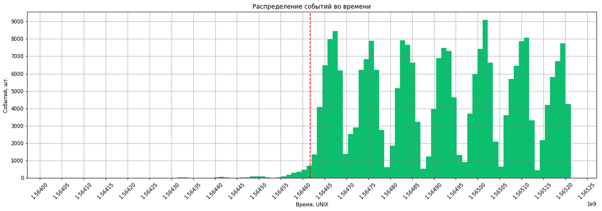

```python
plt.figure(figsize=(20, 6))
ax = plt.subplot()
limit = 1564617600

logs['time_stamp'].plot(kind='hist', bins=100, color='#0BBF6E')
ax.xaxis.set_major_locator(MultipleLocator(base=50000))
plt.xticks(rotation=45)

plt.grid(which='major', color='grey', linewidth=0.5)
ax.yaxis.set_major_locator(MultipleLocator(base=1000))
plt.title('Распределение событий во времени')
plt.xlabel('Время, UNIX')
plt.ylabel('Событий, шт.')

plt.axvline(x=limit, color='#FF0000', linestyle='--')

plt.show()
```

Как видно, до некоторого момента (на графике выше отмечен красной линией) данные неполные, использовать их для исследования нельзя.

```python
print('Исключили данные до момента {0} по time_stamp, что соответствует {1}.'.
      format(limit, pd.to_datetime(limit, unit='s')))
```

```
Исключили данные до момента 1564617600 по time_stamp, что соответствует 2019-08-01 00:00:00.
```

```python
logs_clean = logs.query('time_stamp >= @limit')
```

```python
print('Исключили {:.2%} событий.'.format(1 - logs_clean.shape[0] / logs.shape[0]))
```

```
Исключили 1.16% событий.
```

```python
print('Исключили {:.2%} уникальных пользователей.'.format(1 - logs_clean['user_id'].nunique() / logs['user_id'].nunique()))
```

```
Исключили 0.23% уникальных пользователей.
```

**Убедились, что в логах есть данные о пользователях из всех трёх групп.**

```python
logs_clean['exp_id'].value_counts()
```

```
248    84563
246    79302
247    77022
Name: exp_id, dtype: int64
```

**Изучили воронку событий.**

**Посмотрели, какие события есть в логах, как часто они встречаются. Отсортировали события по частоте.**

```python
logs_clean['event'].value_counts()
```

```
MainScreenAppear           117328
OffersScreenAppear          46333
CartScreenAppear            42303
PaymentScreenSuccessful     33918
Tutorial                     1005
Name: event, dtype: int64
```

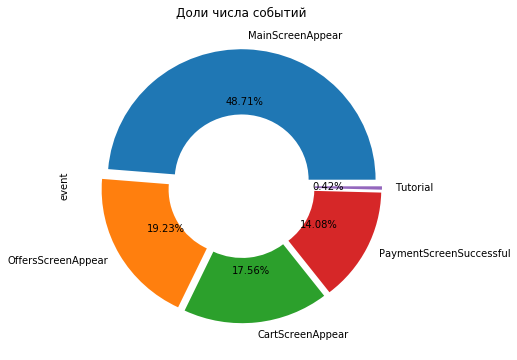

```python
plt.figure(figsize=(6, 6))
logs_clean['event'].value_counts().\
plot(kind='pie', autopct='%0.2f%%', labeldistance=1.1,
     explode=(0.05, 0.05, 0.05, 0.05, 0.05),
     wedgeprops=dict(width=0.5))
plt.title('Доли числа событий')

plt.show()
```

**Определили, сколько пользователей совершали каждое из этих событий, отсортировали события по числу пользователей.**

**Рассчитали долю пользователей, которые хоть раз совершали событие.**

```python
user_events = logs_clean.groupby('event', as_index=False).agg(users=('user_id', 'nunique')).\
sort_values(by='users', ascending=False).reset_index(drop=True)
user_events
```

|  | event | users |
| --- | --- | --- |
| 0 | MainScreenAppear | 7419 |
| 1 | OffersScreenAppear | 4593 |
| 2 | CartScreenAppear | 3734 |
| 3 | PaymentScreenSuccessful | 3539 |
| 4 | Tutorial | 840 |

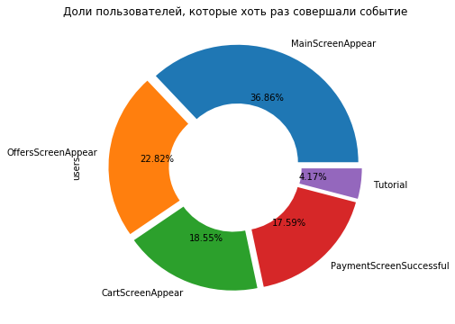

```python
plt.figure(figsize=(6, 6))

user_events['users'].plot(kind='pie', autopct='%0.2f%%', labeldistance=1.1,
                          explode=(0.05, 0.05, 0.05, 0.05, 0.05),
                          wedgeprops=dict(width=0.5),
                          labels=list(user_events['event'].unique()))
plt.title('Доли пользователей, которые хоть раз совершали событие')

plt.show()
```

**Изучили, в каком порядке происходят события и все ли их нужно включать в воронку.**

Из графиков и таблиц выше видно, что воронка состоит из этапов:

`MainScreenAppear` --> `OffersScreenAppear` --> `CartScreenAppear` --> `PaymentScreenSuccessful`.

Вероятно, `tutotial` может совершаться в произвольный момент времени, когда пользователь хочет узнать правила работы магазина.

Исключили событие `tutotial` из дальнейшего рассмотрения.

```python
logs_clean_funnel = logs_clean.query('event != "Tutorial"')
```

```python
print('Исключили {:.2%} событий.'.format(1 - logs_clean_funnel.shape[0] / logs_clean.shape[0]))
```

```
Исключили 0.42% событий.
```

**Рассчитали, какая доля пользователей от числа пользователей на предыдущем этапе переходит на следующий этап воронки.**

```python
user_funnel = logs_clean_funnel.groupby('event', as_index=False).agg(users=('user_id', 'nunique')).\
sort_values(by='users', ascending=False).reset_index(drop=True)
user_funnel['delta'] = user_funnel['users'].pct_change(periods=1, axis=0).fillna(0)
user_funnel['share'] = (user_funnel['users'].pct_change(periods=1, axis=0) + 1).fillna(0)
user_funnel.style.format({'delta':'{:.2%}', 'share':'{:.2%}'})
```

|  | event | users | delta | share |
| --- | --- | --- | --- | --- |
| 0 | MainScreenAppear | 7419 | 0.00% | 0.00% |
| 1 | OffersScreenAppear | 4593 | -38.09% | 61.91% |
| 2 | CartScreenAppear | 3734 | -18.70% | 81.30% |
| 3 | PaymentScreenSuccessful | 3539 | -5.22% | 94.78% |

Здесь в `delta` указана величина изменения количества, в `share` -- доля по отношению к предыдущему событию.

Видно, что более трети пользователей "отваливается" при переходе к заказу товаров. Из числа заказавших к Корзине не переходят ещё примерно 18 %. Наименьшие потери -- на финальной стадии `PaymentScreenSuccessful`.

```python
comm_events_users = logs_clean_funnel.pivot_table(index='date', columns='event', values='user_id', aggfunc='count').\
reset_index()
comm_events_uniq_users = logs_clean_funnel.pivot_table(index='date', columns='event', values='user_id', aggfunc='nunique').\
reset_index()
comm_events_users['date'] = comm_events_users['date'].astype('str')
comm_events_users['date'] = comm_events_users['date'].map(lambda x: dt.datetime.strptime(x, '%Y-%m-%d'))
comm_events_uniq_users['date'] = comm_events_uniq_users['date'].astype('str')
comm_events_uniq_users['date'] = comm_events_uniq_users['date'].map(lambda x: dt.datetime.strptime(x, '%Y-%m-%d'))
```

Построили графики изменения количества пользователей (слева) и количества уникальных пользователей (справа), которые совершали события.

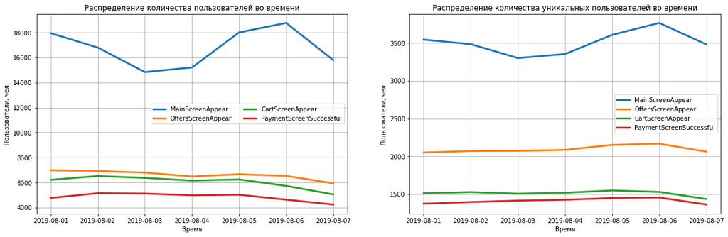

```python
plt.figure(figsize=(20, 6))

ax1 = plt.subplot(1, 2, 1)
for event in list(logs_clean_funnel['event'].unique()):
    ax1.plot(comm_events_users['date'], comm_events_users[event], linewidth=3)
ax1.grid(which='major', color='grey', linewidth=0.5)
plt.legend(['MainScreenAppear', 'OffersScreenAppear', 'CartScreenAppear', 'PaymentScreenSuccessful'], ncol=2)
plt.title('Распределение количества пользователей во времени')
plt.xlabel('Время')
plt.ylabel('Пользователи, чел.')

ax2 = plt.subplot(1, 2, 2)
for event in list(logs_clean_funnel['event'].unique()):
    ax2.plot(comm_events_uniq_users['date'], comm_events_uniq_users[event], linewidth=3)
ax2.grid(which='major', color='grey', linewidth=0.5)
plt.legend(['MainScreenAppear', 'OffersScreenAppear', 'CartScreenAppear', 'PaymentScreenSuccessful'])
plt.title('Распределение количества уникальных пользователей во времени')
plt.xlabel('Время')
plt.ylabel('Пользователи, чел.')

plt.show()
```

Как видно, оба показателя во времени распределены примерно одинаково. Заметны падения показателей в выходные дни и оживление в течение рабочих дней.

```python
comm_events_users['delta_3_4'] = comm_events_users['CartScreenAppear'] - comm_events_users['PaymentScreenSuccessful']
comm_events_users['delta_2_3'] = comm_events_users['OffersScreenAppear'] - comm_events_users['CartScreenAppear']
comm_events_users['delta_1_2'] = comm_events_users['MainScreenAppear'] - comm_events_users['OffersScreenAppear']
```

```python
comm_events_uniq_users['delta_3_4'] = comm_events_uniq_users['CartScreenAppear'] - comm_events_uniq_users['PaymentScreenSuccessful']
comm_events_uniq_users['delta_2_3'] = comm_events_uniq_users['OffersScreenAppear'] - comm_events_uniq_users['CartScreenAppear']
comm_events_uniq_users['delta_1_2'] = comm_events_uniq_users['MainScreenAppear'] - comm_events_uniq_users['OffersScreenAppear']
```

```python
comm_events_users['date'] = comm_events_users['date'].astype('str')
comm_events_uniq_users['date'] = comm_events_uniq_users['date'].astype('str')
```

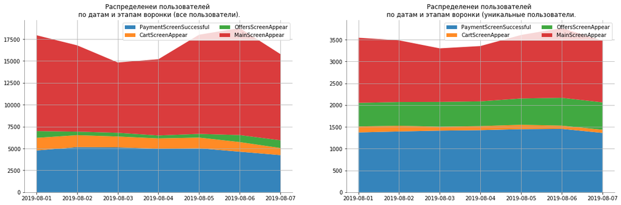

```python
plt.figure(figsize=(20, 6))

ax1 = plt.subplot(1, 2, 1)
ax1.x = comm_events_users['date'].tolist()
ax1.y1 = comm_events_users['PaymentScreenSuccessful'].tolist()
ax1.y2 = comm_events_users['delta_3_4'].tolist()
ax1.y3 = comm_events_users['delta_2_3'].tolist()
ax1.y4 = comm_events_users['delta_1_2'].tolist()
ax1.y = np.vstack([ax1.y1, ax1.y2, ax1.y3, ax1.y4])
ax1.stackplot(ax1.x, ax1.y, alpha=0.9)
ax1.spines["top"].set_alpha(0)
ax1.spines["bottom"].set_alpha(0.5)
ax1.spines["right"].set_alpha(0)
ax1.spines["left"].set_alpha(0.5)
ax1.set_title('Распределенеи пользователей \n по датам и этапам воронки (все пользователи).')
plt.legend(['PaymentScreenSuccessful', 'CartScreenAppear', 'OffersScreenAppear', 'MainScreenAppear'], ncol=2)
plt.grid()

ax2 = plt.subplot(1, 2, 2)
ax2.x = comm_events_users['date'].tolist()
ax2.y1 = comm_events_uniq_users['PaymentScreenSuccessful'].tolist()
ax2.y2 = comm_events_uniq_users['delta_3_4'].tolist()
ax2.y3 = comm_events_uniq_users['delta_2_3'].tolist()
ax2.y4 = comm_events_uniq_users['delta_1_2'].tolist()
ax2.y = np.vstack([ax2.y1, ax2.y2, ax2.y3, ax2.y4])
ax2.stackplot(ax2.x, ax2.y, alpha=0.9)
ax2.spines["top"].set_alpha(0)
ax2.spines["bottom"].set_alpha(0.5)
ax2.spines["right"].set_alpha(0)
ax2.spines["left"].set_alpha(0.5)
ax2.set_title('Распределенеи пользователей \n по датам и этапам воронки (уникальные пользователи.')
plt.legend(['PaymentScreenSuccessful', 'CartScreenAppear', 'OffersScreenAppear', 'MainScreenAppear'], ncol=2)
plt.grid()

plt.show()
```

**Определили, на каком шаге теряете больше всего пользователей.**

```python
user_funnel.sort_values(by='delta').style.format({'delta':'{:.2%}', 'share':'{:.2%}'})
```

|  | event | users | delta | share |
| --- | --- | --- | --- | --- |
| 1 | OffersScreenAppear | 4593 | -38.09% | 61.91% |
| 2 | CartScreenAppear | 3734 | -18.70% | 81.30% |
| 3 | PaymentScreenSuccessful | 3539 | -5.22% | 94.78% |
| 0 | MainScreenAppear | 7419 | 0.00% | 0.00% |

Как видно, больше всего пользователей теряется на стадии `OffersScreenAppear`.

Это можно объяснить особенностями поведения пользователей: пользователь или не подбирает себе покупку или, уж если подобрал, то с высокой вероятностью доходит до её оплаты.

У магазина, вероятно, нет технических проблем с оплатой товаров и работой Корзины.

Однако стоит уделить внимание переходу к Корзине: около 18 % пользователей из числа выбравших товар до неё не доходят.

**Определили, какая доля пользователей доходит от первого события до оплаты.**

```python
print('От первого события до оплаты доходят {:.2%} пользователей.'.format(user_funnel.loc[3]['users'] / user_funnel.loc[0]['users']))
```

```
От первого события до оплаты доходят 47.70% пользователей.
```

**Промежуточные выводы:**

- всего в логе 243713 событий;
- всего в логе 7551 уникальных пользователей;
- в среднем на одного уникального пользователя приходится 32.28 событий;
- исходные данные в диапазоне: 2019-07-25 -- 2019-08-07;
- исключили данные до момента 1564617600 по time_stamp, что соответствует 2019-08-01 00:00:00, что составило 1.16% событий;
- изучили воронку событий;
- рассчитали долю пользователей, которые хоть раз совершали событие;
- воронка состоит из этапов: MainScreenAppear --> OffersScreenAppear --> CartScreenAppear --> PaymentScreenSuccessful;
- исключили событие tutotial из дальнейшего рассмотрения как не входящее в воронку;
- более трети пользователей "отваливается" при переходе к заказу товаров; из числа заказавших к Корзине не переходят ещё примерно 18 %; наименьшие потери -- на финальной стадии PaymentScreenSuccessful;
- больше всего пользователей теряется на стадии OffersScreenAppear.
- от первого события до оплаты доходят 47.70% пользователей.

## Часть 3. Изучение результатов эксперимента.

**Определили, сколько пользователей в каждой группе.**

246 и 247 — контрольные группы, 248 — экспериментальная.

```python
logs_clean_funnel.groupby('exp_id').agg(users=('user_id', 'nunique'))
```

| exp_id | users |
| --- | --- |
| 246 | 2483 |
| 247 | 2512 |
| 248 | 2535 |

Проверили, что в разные группы попали разные пользователи.

```python
users_246 = logs_clean_funnel.query('exp_id == 246')['user_id'].unique()
users_247 = logs_clean_funnel.query('exp_id == 247')['user_id'].unique()
users_248 = logs_clean_funnel.query('exp_id == 248')['user_id'].unique()
```

```python
list(set(users_246) & set(users_247))
```

```
[]
```

```python
list(set(users_246) & set(users_248))
```

```
[]
```

```python
list(set(users_247) & set(users_248))
```

```
[]
```

В разные группы попали разные пользователи.

**Выбрали самое популярное событие.**

Посчитали число пользователей, совершивших это событие в каждой из контрольных групп.

Посчитали долю пользователей, совершивших это событие.

**Для группы 246:**

```python
events_246 = logs_clean_funnel.query('exp_id == 246').\
groupby('event').agg(events=('user_id', 'count'), users=('user_id', 'nunique')).\
sort_values(by='users', ascending=False)
events_246['share'] = events_246['users'].map(lambda x: x / logs_clean_funnel.query('exp_id == 246')['user_id'].nunique())
events_246.style.format({'share':'{:.3f}'})
```

| event | events | users | share |
| --- | --- | --- | --- |
| MainScreenAppear | 37676 | 2450 | 0.987 |
| OffersScreenAppear | 14767 | 1542 | 0.621 |
| CartScreenAppear | 14690 | 1266 | 0.510 |
| PaymentScreenSuccessful | 11852 | 1200 | 0.483 |

**Для группы 247:**

```python
events_247 = logs_clean_funnel.query('exp_id == 247').\
groupby('event').agg(events=('user_id', 'count'), users=('user_id', 'nunique')).\
sort_values(by='users', ascending=False)
events_247['share'] = events_247['users'].map(lambda x: x / logs_clean_funnel.query('exp_id == 247')['user_id'].nunique())
events_247.style.format({'share':'{:.3f}'})
```

| event | events | users | share |
| --- | --- | --- | --- |
| MainScreenAppear | 39090 | 2476 | 0.986 |
| OffersScreenAppear | 15179 | 1520 | 0.605 |
| CartScreenAppear | 12434 | 1238 | 0.493 |
| PaymentScreenSuccessful | 9981 | 1158 | 0.461 |

**Для группы 248:**

```python
events_248 = logs_clean_funnel.query('exp_id == 248').\
groupby('event').agg(events=('user_id', 'count'), users=('user_id', 'nunique')).\
sort_values(by='users', ascending=False)
events_248['share'] = events_248['users'].map(lambda x: x / logs_clean_funnel.query('exp_id == 248')['user_id'].nunique())
events_248.style.format({'share':'{:.3f}'})
```

| event | events | users | share |
| --- | --- | --- | --- |
| MainScreenAppear | 40562 | 2493 | 0.983 |
| OffersScreenAppear | 16387 | 1531 | 0.604 |
| CartScreenAppear | 15179 | 1230 | 0.485 |
| PaymentScreenSuccessful | 12085 | 1181 | 0.466 |

Как видно, наиболее популярное событие -- `MainScreenAppear`.

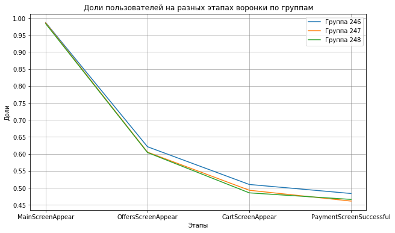

```python
plt.figure(figsize=(10, 6))
ax = plt.subplot()

plt.plot(events_246['share'])
plt.plot(events_247['share'])
plt.plot(events_248['share'])

ax.yaxis.set_major_locator(MultipleLocator(base=0.05))
plt.grid(which='major', color='grey', linewidth=0.5)
plt.title('Доли пользователей на разных этапах воронки по группам')
plt.legend(['Группа 246', 'Группа 247', 'Группа 248'])
plt.xlabel('Этапы')
plt.ylabel('Доли')

plt.show()
```

**Проверили, будет ли отличие между группами статистически достоверным.**

Выдвинули нулевую и альтернативную гипотезы:

H_0: Статистически значимых различий между долями пользователей, совершивших событие, нет.

H_a: Статистически значимые различия между долями пользователей, совершивших событие, есть.

Пороговое значение alpha = 0.05. Это приемлемый уровень достоверности.

Здесь и далее формулировки гипотез **не меняются.**

Для проверки использовали функцию:

```python
def share_test(event, x, y):
    alpha = 0.05
    users_in_event = np.array([logs_clean_funnel.query('exp_id == @x').\
                               groupby('event').agg(events=('user_id', 'count'), users=('user_id', 'nunique')).\
                               loc[event, 'users'],
                               logs_clean_funnel.query('exp_id == @y').\
                               groupby('event').agg(events=('user_id', 'count'), users=('user_id', 'nunique')).\
                               loc[event, 'users']])
    users_in_group = np.array([logs_clean_funnel.groupby('exp_id').agg(users=('user_id', 'nunique')).\
                               loc[x, 'users'],\
                               logs_clean_funnel.groupby('exp_id').agg(users=('user_id', 'nunique')).\
                               loc[y, 'users']])
    p1 = users_in_event[0]/users_in_group[0]
    p2 = users_in_event[1]/users_in_group[1]
    p_combined = (users_in_event[0] + users_in_event[1]) / (users_in_group[0] + users_in_group[1])
    difference = p1 - p2
    z_value = difference / mth.sqrt(p_combined * (1 - p_combined) * (1/users_in_group[0] + 1/users_in_group[1]))
    distr = st.norm(0, 1)
    p_value = (1 - distr.cdf(abs(z_value))) * 2
    if p_value < alpha:
        print('Отвергаем нулевую гипотезу: между долями есть значимая разница.')
    else:
        print('Статистически значимых различий между долями пользователей, совершивших событие, нет.')

    return print('Событие: {0}, группы: {1} и {2}. p-значение: {3}'.format(event, x, y, p_value))
```

**Проверили, существует ли статистическая разница между группами 246 и 247.**

```python
for event in list(logs_clean_funnel['event'].unique()):
    share_test(event, 246, 247)
```

```
Статистически значимых различий между долями пользователей, совершивших событие, нет.
Событие: MainScreenAppear, группы: 246 и 247. p-значение: 0.7526703436483038
Статистически значимых различий между долями пользователей, совершивших событие, нет.
Событие: OffersScreenAppear, группы: 246 и 247. p-значение: 0.24786096925282264
Статистически значимых различий между долями пользователей, совершивших событие, нет.
Событие: CartScreenAppear, группы: 246 и 247. p-значение: 0.22867643757335676
Статистически значимых различий между долями пользователей, совершивших событие, нет.
Событие: PaymentScreenSuccessful, группы: 246 и 247. p-значение: 0.11446627829276612
```

Как видно, ни по одному событию не обнаружена статистически значимая разница между долями пользователей в группах 246 и 247.

Это означает, что эти 2 контрольные группы **сформированы корректно**.

**Сравнили результаты группы 248 с каждой из контрольных групп в отдельности по каждому событию.**

```python
for event in list(logs_clean_funnel['event'].unique()):
    share_test(event, 246, 248)
```

```
Статистически значимых различий между долями пользователей, совершивших событие, нет.
Событие: MainScreenAppear, группы: 246 и 248. p-значение: 0.3387114076159288
Статистически значимых различий между долями пользователей, совершивших событие, нет.
Событие: OffersScreenAppear, группы: 246 и 248. p-значение: 0.21442476639710506
Статистически значимых различий между долями пользователей, совершивших событие, нет.
Событие: CartScreenAppear, группы: 246 и 248. p-значение: 0.08067367598823139
Статистически значимых различий между долями пользователей, совершивших событие, нет.
Событие: PaymentScreenSuccessful, группы: 246 и 248. p-значение: 0.21693033984516674
```

```python
for event in list(logs_clean_funnel['event'].unique()):
    share_test(event, 247, 248)
```

```
Статистически значимых различий между долями пользователей, совершивших событие, нет.
Событие: MainScreenAppear, группы: 247 и 248. p-значение: 0.5194964354051703
Статистически значимых различий между долями пользователей, совершивших событие, нет.
Событие: OffersScreenAppear, группы: 247 и 248. p-значение: 0.9333751305879443
Статистически значимых различий между долями пользователей, совершивших событие, нет.
Событие: CartScreenAppear, группы: 247 и 248. p-значение: 0.5878284605111943
Статистически значимых различий между долями пользователей, совершивших событие, нет.
Событие: PaymentScreenSuccessful, группы: 247 и 248. p-значение: 0.7275718682261119
```

Как видно, ни по одному событию не обнаружена статистически значимая разница между долями пользователей в контрольных группах 246, 247 и экспериментальной группе 248.

Это означает, что **эффект от внедрения нового шрифта не обнаружен.**

**Сравнили результаты группы 248 с объединённой контрольной группой.**

Использовали незначительно модернизированную функцию.

```python
def share_test_summ(event):
    alpha = 0.05
    users_in_event = np.array([logs_clean_funnel.query('exp_id in[246, 247]').\
                               groupby('event').agg(events=('user_id', 'count'), users=('user_id', 'nunique')).\
                               loc[event, 'users'],
                               logs_clean_funnel.query('exp_id == 248').\
                               groupby('event').agg(events=('user_id', 'count'), users=('user_id', 'nunique')).\
                               loc[event, 'users']])
    users_in_group = np.array([logs_clean_funnel.groupby('exp_id').agg(users=('user_id', 'nunique')).\
                               loc[246, 'users'] +\
                               logs_clean_funnel.groupby('exp_id').agg(users=('user_id', 'nunique')).\
                               loc[247, 'users'],\
                               logs_clean_funnel.groupby('exp_id').agg(users=('user_id', 'nunique')).\
                               loc[248, 'users']])
    p1 = users_in_event[0]/users_in_group[0]
    p2 = users_in_event[1]/users_in_group[1]
    p_combined = (users_in_event[0] + users_in_event[1]) / (users_in_group[0] + users_in_group[1])
    difference = p1 - p2
    z_value = difference / mth.sqrt(p_combined * (1 - p_combined) * (1/users_in_group[0] + 1/users_in_group[1]))
    distr = st.norm(0, 1)
    p_value = (1 - distr.cdf(abs(z_value))) * 2
    if p_value < alpha:
        print('Отвергаем нулевую гипотезу: между долями есть значимая разница.')
    else:
        print('Статистически значимых различий между долями пользователей, совершивших событие, нет.')

    return print('Событие: {0}, группы: объединённая контрольная и 248. p-значение: {1}'.format(event, p_value))
```

```python
for event in list(logs_clean_funnel['event'].unique()):
    share_test_summ(event)
```

```
Статистически значимых различий между долями пользователей, совершивших событие, нет.
Событие: MainScreenAppear, группы: объединённая контрольная и 248. p-значение: 0.3486684291093256
Статистически значимых различий между долями пользователей, совершивших событие, нет.
Событие: OffersScreenAppear, группы: объединённая контрольная и 248. p-значение: 0.44582745409482394
Статистически значимых различий между долями пользователей, совершивших событие, нет.
Событие: CartScreenAppear, группы: объединённая контрольная и 248. p-значение: 0.18683558686831558
Статистически значимых различий между долями пользователей, совершивших событие, нет.
Событие: PaymentScreenSuccessful, группы: объединённая контрольная и 248. p-значение: 0.6107918742187335
```

Как видно, ни по одному событию не обнаружена статистически значимая разница между долями пользователей в объединённой контрольной группе и экспериментальной группе 248.

Это означает, что **эффект от внедрения нового шрифта не обнаружен.**

```python
print('Всего сделано проверок статистических гипотез: {} штук.'.format(logs_clean_funnel['event'].nunique() * 4))
```

```
Всего сделано проверок статистических гипотез: 16 штук.
```

**Промежуточные выводы:**

- наиболее популярное событие -- MainScreenAppear;
- посчитали число пользователей, совершивших это событие в каждой из контрольных групп;
- посчитали долю пользователей, совершивших это событие;
- проверили, будет ли отличие между группами статистически достоверным;
- в группах 246 и 247 ни по одному событию не обнаружена статистически значимая разница между долями пользователей, которые это событие совершили; это означает, что эти 2 контрольные группы сформированы корректно;
- в контрольных группах 246, 247 и экспериментальной группе 248 ни по одному событию не обнаружена статистически значимая разница между долями пользователей, которые это событие совершили; это означает, что эффект от внедрения нового шрифта не обнаружен;
- в объединённой контрольной группе и экспериментальной группе 248 ни по одному событию не обнаружена статистически значимая разница между долями пользователей, которые это событие совершили; это означает, что эффект от внедрения нового шрифта не обнаружен;
- всего сделано 16 проверок статистических гипотез.

## Общие выводы.

1. Были изучены данные о поведении пользователей интернет-магазина "Продукты питания"; данные соответствуют описанию.
2. В данные были внесены минимальные коррективы: удалено незначительное число дубликатов, преобразованы данные о датах.
3. Всего в логе 243713 событий;
4. Всего в логе 7551 уникальных пользователей.
5. В среднем на одного уникального пользователя приходится 32.28 событий.
6. Исходные данные были представлены в диапазоне: 2019-07-25 -- 2019-08-07; исключили неполные данные до момента 1564617600 по time_stamp, что соответствует 2019-08-01 00:00:00, что составило 1.16% событий.
7. Изучили воронку событий.
8. Рассчитали долю пользователей, которые хоть раз совершали событие.
9. Воронка состоит из этапов: MainScreenAppear --> OffersScreenAppear --> CartScreenAppear --> PaymentScreenSuccessful; исключили событие tutotial из дальнейшего рассмотрения как не входящее в воронку.
10. Более трети пользователей "отваливается" при переходе к заказу товаров; из числа заказавших к Корзине не переходят ещё примерно 18 %; наименьшие потери -- на финальной стадии PaymentScreenSuccessful.
11. Больше всего пользователей теряется на стадии OffersScreenAppear.
12. От первого события до оплаты доходят 47.70% пользователей.
13. Наиболее популярное событие -- MainScreenAppear; рассчитали число пользователей, совершивших это событие в каждой из контрольных групп; рассчитали долю пользователей, совершивших это событие.
14. Проверили, будет ли отличие между группами статистически достоверным. Всего сделано 16 проверок статистических гипотез.
15. В группах 246 и 247 ни по одному событию не обнаружена статистически значимая разница между долями пользователей, которые это событие совершили; это означает, что эти 2 контрольные группы сформированы корректно.
16. В контрольных группах 246, 247 и экспериментальной группе 248 ни по одному событию не обнаружена статистически значимая разница между долями пользователей, которые это событие совершили; это означает, что эффект от внедрения нового шрифта не обнаружен.
17. В объединённой контрольной группе и экспериментальной группе 248 ни по одному событию не обнаружена статистически значимая разница между долями пользователей, которые это событие совершили; это означает, что эффект от внедрения нового шрифта не обнаружен.